# Proyecto 2 Grafico-DADA2-Secuenciacion

# Grafico agrupado por líneas con variabe del primer proyecto

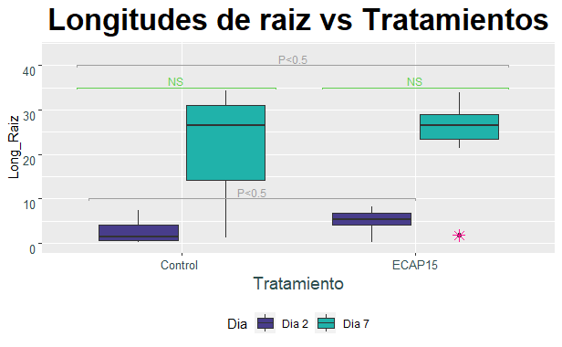

# Secuenciación de muestra de VID (S81)

```r
list.files(path)
```

```
[1] "1VS81_R1_001.fastq.gz" "1VS81_R2_001.fastq.gz"
```

## Inspección perfiles de calidad

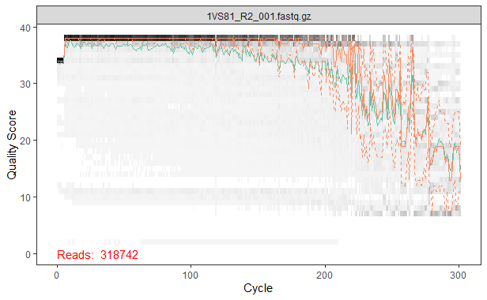

## Corte

```r
out <- filterAndTrim(fnFs, filtFs, # forward reads
                     fnRs, filtRs, # reverse reads
                     truncLen = c(230,200), # truncado o corte
                     maxN = 0, # remover Ns, ESTE NUNCA SE PUEDE MODIFICAR
                     maxEE = c(2,5), #error esperado, lo estandar es 2,2 pero se recomienda que para reverse sea 5
                     truncQ = 2, #quality score
                     rm.phix = TRUE, compress = TRUE, #defaults
                     multithread = FALSE) # en windows
```

```
Creating output directory: C:/Users/cvillalobos/Documents/RStudio/CursoInnovak/Secuenciacion_proyecto_2//filtered
```

## Tasas de error

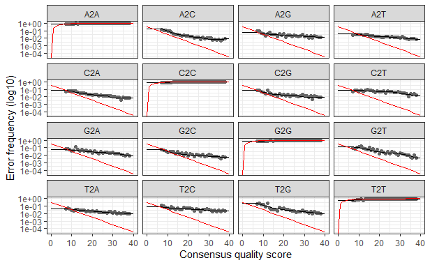

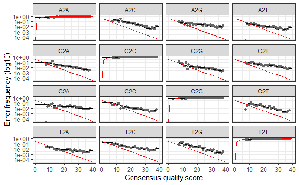

*Interpretación errores* Al graficar los errores se observan las posibles combinaciones que existen en la muestra, esto nos ayuda para poder saber si hay diferencia en las bases (en este caso seria entre una misma secuencia). * Las lineas negras representan las tasas de error estimadas que basicamente son los ajustes de los datos reales pero que ya cuentan con los errores. * Las lineas rojas representan las tasas de error esperadas que son los datos reales. Así, tendríamos en cuenta que en cada secuencia/muestra(as) que porcesemos, la tasa de error debe ser menor cuando la calidad sea mayor en estas graficas. Que si observamos, nuestras graficas nos arrojan que tenemos mayor calidad.

# Interferencia de las muestras

```r
dadaRs_nopool_proy2 <- dada(filtRs, err=errR, multithread = TRUE,
                      pool = FALSE)
```

```
Sample 1 - 291997 reads in 161627 unique sequences.
```

```r
save(dadaRs_nopool_proy2, file = "dadaRs_nopool_proy2.RData")
```

*Interpretación* En relación a la interferencia de las muestras, nos dice cuantos errores fueron descartados para dejar limpia nuestra secuecia.

# Union de las lecturas forwards y reverse

```r
mergers_proy2 <- mergePairs(dadaFs_nopool_proy2_1, filtFs, dadaRs_nopool_proy2, filtRs, verbose = TRUE)
```

[output not shown]

[output not shown]

# Hacer tabla de secuencias

```r
# Sequence table
seqtab_proy2 <- makeSequenceTable(mergers_proy2)
dim(seqtab_proy2) #numero de muestras x numero de ASVs

# Checar la longitud de todas las secuencias
table(nchar(getSequences(seqtab_proy2)))
```

[output not shown]

# Quitar quimeras

```r
seqtab.nochim_proy2 <- removeBimeraDenovo(seqtab_proy2, method = "consensus",
                                    multithread=TRUE, verbose = TRUE)
#identified 36 bimeras out 148 input sequences. Añadir a reporte
#Basado en esto (dividir 36/148*100) 24% de mis secuencias son quimeras

save(seqtab.nochim_proy2, file = "seq_conteos_proy2.RData")
load("seq_conteos_proy2.RData")

# Comparar esta tabla con la original que incluye quimeras
dim(seqtab.nochim_proy2)
# Incluyendo abundancias
sum(seqtab.nochim_proy2)/sum(seqtab_proy2) # porcentaje de secuencias no quimericas que se mantuvieron

# Tomando en cuenta abundancias en realidad mantuvimos 92% de nuestras lecturas
```

[output not shown]

# Seguimiento del proceso

```r
# Nombramos nuestras filas y columnas
colnames(track_proy2) <- c("input", "filtered", "denoisedF", "denoisedR", "merged", "nonchim")
```

[output not shown]

# Asignar Taxonomia

```r
taxa_proy2_esp <- addSpecies(taxa, "~/RStudio/CursoInnovak/Secuenciación/Taxa/silva_species_assignment_v138.1.fa.gz")
```

[output not shown]